# Knowledge is built, not received

Week 7 · Chapter 8 · Cognitive Learning Theory and Principles of Learning

Study · Week 7

Read Chapter 8 first, then this. Last week was about how little the brain can hold. This week is about what it does with what gets in and why a learner can hold every fact correctly and still understand nothing.

About 13 minutes, including the two places you stop and write.

Pair this with **the Walkthrough**.

## Before you read: PISA 2025

- **Scores are falling.** Across the OECD, 15-year-olds’ reading and math are at their lowest on record, and the steepest fall is in evaluating information and reasoning from sources.

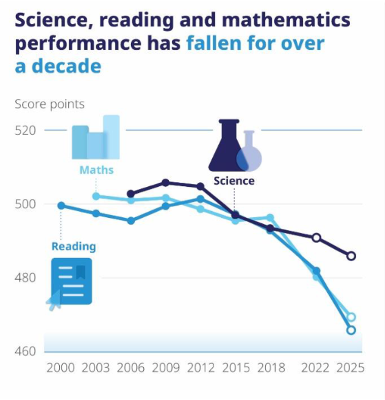

OECD average PISA scores, 2000–2025. Source: OECD, PISA 2025 Results.

- **AI use is rising, and how students use it matters.** About half of OECD 15-year-olds use AI every week to learn. Those who use it daily to summarize or draft score lower than those who never do. Singapore has one of the highest AI-use rates and still ranks second in the world.
- **Watch** the OECD’s short video below. The question: if a chatbot can deliver the content, what is school for? *In person:* bring your answer to Tuesday’s class. *Online:* think it through as you work this week.

[video not shown]

If the video does not load: [watch it on YouTube](https://www.youtube.com/watch?v=MiHzd0aTIkA).

## A believe novice teachers may have

**If an explanation is clear enough, the student will understand.** Every teacher believes it a little; it is why we work so hard on the explanations. If it were true, the best-explained subjects would have no misconceptions, and Priya (who wrote down every clear explanation she was given) would have scored 8 of 8.

The last line of the principle list below is the one the whole chapter argues for, and it is the one that changes what a lesson is for.

## Eight principles, and the one that matters most

Chapter 8’s constructivism, as a list you can design from. Each one has a cost — ask *what is the disadvantage?* of every line, because a principle without a cost is a slogan.

Learners actively construct knowledge Not received, built — out of whatever is already there. *Cost:* what they build may not be what you taught.

Prior knowledge shapes new learning The schema does the interpreting. Same explanation, different heads, different lessons. *Cost:* you have to know what is in there first, and you usually do not.

Learners seek coherence and meaning When the new fact does not fit, they will make it fit — assimilation, from Week 3 — or set it aside. *Cost:* a coherent wrong model is more stable than an incoherent right one.

Practice is essential for long-term learning Retrieval, spacing, generation — Week 6. *Cost:* practice of the wrong thing entrenches it.

Deep understanding requires meaningful learning Ausubel’s word: *meaningful* means attached to structure; *rote* means attached to nothing. Both can produce a correct answer on Friday. Only one survives to March.

Connecting to the real world enhances learning More retrieval routes, more transfer. *Cost:* the real-world wrapper can hide the structure — Week 8’s whole case.

Interaction supports learning and conceptual change Vygotsky’s argument, now with a mechanism: having to explain, defend or argue forces the schema out where it can be inspected. *Cost:* time, noise, and the teacher not being the one talking.

Explanation alone is insufficient **The one that matters most.** A clear explanation is an input to construction, not a substitute for it. What the learner *does* after the explanation is where the learning is.

Read the last principle against your own experience of being taught: the lessons you remember are almost never the clearest explanations. They are the times you had to **do something with it** — argue, build, predict, be wrong in public.

## Meaningful vs rote learning and how to tell them apart

Ausubel’s distinction, and the one Priya’s case turns on.

Rote learning — stored verbatim, attached to nothing Retrievable when the cue matches the storage: *define osmosis* → the definition. Not retrievable when the cue is a celery stick. This is what a definition on its own is.

Meaningful learning — attached to an existing structure (schema)Retrievable from many directions, because it is connected to many things. The learner can run it forward: *salt outside → water leaves → cell shrinks → limp.*

Inert knowledge — correct, stored, and unused Whitehead’s term. Knowledge the learner has and cannot bring to bear when it is needed. **Priya’s notes are inert.** So is most of what most people remember from school.

Advance organiser — Ausubel’s fix A structure given *before* the content, at a higher level of generality, for the new material to attach to. Not a summary; a scaffold for a schema. *“Water moves toward salt”* before the word *osmosis*.

**Every assessment Priya has met rewarded rote learning and called it understanding.**  
*Define. List. Label.* She has correctly learned what the system measures. Asking *“is there another word I was supposed to use?”* was expected. The test finally asked for explanation, and nobody had told her how to do it.

## Misconceptions, and why explaining does not move them

A misconception is not a missing fact. It is a **coherent, working schema that happens to be wrong** and because it works, in the learner’s experience, it resists replacement with the correct knowledge.

Examples:

*democracy means majority rule* · *evolution means survival of the strongest* · *food with chemical names is dangerous* · and the one for this room — *a teacher who believes **repetition** is the most effective method, and ignores the evidence that elaboration and interaction matter.*

Confirmation bias The schema chooses its evidence. The student who thinks climate change is a hoax finds the articles that agree and rejects the science teacher. This is assimilation with a search engine.

Misinformation effect Exposure to a wrong claim alters the stored knowledge, even when the source is later discredited. What was heard first is sticky.

Conceptual change — the four conditions Posner and colleagues: the learner must be **dissatisfied** with the old idea; the new one must be **intelligible**, **plausible**, and **fruitful**. Notice that a clear explanation supplies only the second.

Explanation delivers *intelligible*. It cannot deliver *dissatisfied* — only an experience where the old idea visibly fails can do that. **That is why interaction, prediction and argument are not enrichment. They are the mechanism.**

Commit first

Two students use the same chatbot to revise osmosis for the same twenty minutes. Both get correct explanations. Ethan reads his, copies and stops. Fabian asks *“why does salt pull water out and not push it in — that seems backwards,”* argues with the answer twice, then asks for a case where his intuition would be right.

**Name the move Fabian made that Ethan did not — as a move, not a personality trait — and say which of the four conditions for conceptual change it produced.** Two or three sentences.

**He put his own schema on the table and made the tool argue with it.**

*“That seems backwards to me”* is a prediction — his prior model, stated. The tool’s answer now has something to collide with, and the collision is **dissatisfaction**: the condition explanation alone cannot supply. Asking for a case where his intuition would be right is elaboration in the other direction — finding the boundary of the new idea, which is what makes it **plausible** and understandable to his current development.

Ethan received an intelligible explanation and it attached to nothing, because nothing was exposed for it to attach to. Same tool, same minutes. The difference is whether the learner did anything.

This is the design question for your own tool, Milestone 2 Part 4: what does it do when it meets the learner’s wrong idea — and how does it *elicit it first*?

## The principles as design — T07

Active processing Any task that makes the learner generate, transform or apply rather than receive (listening to the lecture). The operational form of *explanation alone is insufficient.*

Worked examples — and why they are not cheating For a novice, studying a fully worked solution is better than solving from scratch: it builds the schema without overloading WMC (Week 6). **Then the guidance fades** — complete the last step, then the last two, then solve. A worked example (Scaffolding, Vygotsky) that never fades undermines independence.

Expertise reversal The same worked example that helps a novice *hurts* a learner who already has the schema. It is now extraneous load. Which is why one design for the whole room is wrong for half of it.

Feedback — timing and specificity *Correct/incorrect* is nearly useless. *pointing out where the reasoning fails* is necessary. Immediate feedback helps procedural learning; slightly delayed feedback can help retention. Feedback that tells what to do next helps revision and future tasks.

### On using examples

An example — or an exemplar, a worked case, a model answer is helpful when it:

| **SHOWS** | the final product — what done looks like |
| --- | --- |
| **EXPLAINS** | the hidden process — the steps the expert has automatized |
| **PREDICTS** | expected behaviors and likely contradictions or errors |
| **CONNECTS** | to the students’ world — a retrieval route they already own |
| **ALIGNS** | with how it will be graded — the structure the assessment will actually ask for |

**PREDICTS is the line that does the conceptual-change work**. Use examples that exposes the misconception before the learner makes it turns the learner’s *“that seems backwards”* into part of the lesson. Priya’s teacher had a definition on the board, but it didn’t help them question whether the principle of osmosis made sense to the students.

Just in case you were wondering what the example was about:

[video not shown]

## What the AI twin looks like

A language model has read a very large number of explanations of your topic. When you ask it to teach, it produces the **probable explanation** — the one most often written in its training data. That is also, very often, the one your learners have already been given and already failed with. **AI does not know their misconception unless it is told, and it does not ask.**

Your Friction Move this week (**Verify**) checks exactly this: did the explanation build from what a learner already knows, or state facts in a good order? The tool can do the first — Fabian got it to — but only when the learner’s schema is put in front of it. A tool designed to teach has to be told to ask for the wrong idea first. That instruction is the rule you write in Milestone 2, Part 4.

## Check yourself

Check yourself

A student can define every term in a unit correctly and cannot explain a novel case that uses them. The most precise description of the student challenge is:

Wrong week Nothing here is about capacity. They retrieved every definition perfectly; what is missing is the structure between them.

Close, but they have no conception to be mis- A misconception is a coherent wrong model. They have correct pieces and no model. That is worse in one way — there is nothing to be dissatisfied with — and easier in another.

Yes Stored verbatim, retrievable by the matching cue, unusable when the cue is a celery stick. Ausubel’s rote; Whitehead’s inert. And multiple choice and memory tests reward this.

The diagnosis that requires nothing of the teacher She takes color-coded notes and came to ask about the grade. Whatever this is, it is not a lack of effort.

Check yourself

A teacher discovers that a third of the class believes heavier objects fall faster. She explains, clearly and with a diagram, that they do not. Two weeks later a third of the class believes heavier objects fall faster. By Chapter 8, the most likely reason is:

The intuitive answer, and the chapter’s target A clearer explanation is a better version of the thing that did not work. Explanation helps with *clarity*; but it can failt to *accommodate*.

Yes The old model still works in their experience — a feather does fall slower. Until they predict, watch it fail, and have to account for it, the new idea is a fact they were told sitting beside a model they use. Conceptual change needs the challenge.

Not established, and not sufficient Attending perfectly to an explanation still produces only intelligibility. This is the Week 6 explanation for a Week 8 problem.

Wrong mechanism Interference is competition between stored material. This is the original schema surviving intact because nothing displaced it.

By now you should **Have an answer to case question 1** — what Priya has, and what she does not, in the chapter’s words.

**One misconception in your own subject** that survives being explained.

**Your Fabian move** — the last time you argued with a tool instead of reading it. If you cannot think of one, that is a finding.

*This week feeds Milestone 2, Parts 2 and 4 — what must be held versus connected, and what your tool does when it meets the wrong idea.*

## Sources

Ausubel, D. P. (1968). *Educational psychology: A cognitive view.* Holt, Rinehart and Winston.

Vygotsky, L. S. (1978). *Mind in society: The development of higher psychological processes.* Harvard University Press.

OECD. (2026). *PISA 2025 results (Volume I).* OECD Publishing.

Schraw, G., & Dennison, R. S. (1994). Assessing metacognitive awareness. *Contemporary Educational Psychology, 19*(4), 460–475.